# UEFA Champions League: Tactical & Performance Analysis

Harvey Gonzalez, Alexi Umana, Samuel Nunez

5-4-2026

# 1 Introduction

This report analyzes event-level data from UEFA Champions League matches using StatsBomb’s open-data repository. StatsBomb provides one of the most granular publicly available soccer datasets, capturing every on-ball action — passes, shots, tackles, pressures, and more — down to the exact pitch coordinates and timestamps.

Our analysis focuses on five core questions:

1. Which players are caught in an offside position most frequently?
2. Do home teams score more goals than away teams on average?
3. Does a higher volume of defensive actions correlate with winning?
4. Where on the pitch do Champions League shots originate, and how does conversion rate vary by zone?
5. How does expected goals (xG) change with distance from goal, and what are the outcomes of penalty kicks?

All data is loaded directly from the [StatsBomb Open Data GitHub repository](https://github.com/statsbomb/open-data) via the `StatsBombR` package.

# 2 Data & Methods

## 2.1 Packages

```r
# install.packages("devtools")
# devtools::install_github("statsbomb/StatsBombR")
# install.packages("ggsoccer")

library(tidyverse)
library(knitr)
library(kableExtra)
library(ggsoccer)
library(StatsBombR)

# StatsBombR dependencies
library(stringi); library(rvest); library(RCurl)
library(foreach); library(iterators); library(parallel)
library(httr); library(jsonlite); library(sp)
```

## 2.2 Data Loading

We pull every available Champions League competition from StatsBomb’s free data, then loop through all associated matches to collect event-level records. The final dataset contains one row per on-ball event.

```r
invisible(capture.output(
  Comp <- FreeCompetitions()
))

champLeagues_Comp <- Comp %>%
  filter(competition_name == "Champions League")

invisible(capture.output(
  Matches <- FreeMatches(champLeagues_Comp)
))

champLeagues_events <- list()

invisible(capture.output(
  for (i in 1:nrow(Matches)) {
    match_data <- get.matchFree(Matches[i, ])
    champLeagues_events[[i]] <- match_data
  }
))

champLeagues_events <- bind_rows(champLeagues_events)
```

## 2.3 Key Variables

The table below defines the most important fields used throughout this analysis.

Key variables used in this analysis.

| Variable | Description |
| --- | --- |
| player.name | Name of the primary player involved in the event |
| type.name | Event category (e.g., Pass, Shot, Tackle, Pressure) |
| pass.outcome.name | Result of a pass attempt (e.g., Pass Offside, Complete) |
| pass.recipient.name | Intended target of a pass — used to identify who was offside |
| shot.statsbomb_xg | Expected goals (xG): model-estimated probability this shot results in a goal |
| shot.outcome.name | Outcome of a shot (Goal, Saved, Off T, Post) |
| shot.type.name | Shot type (Open Play, Free Kick, Penalty, Corner) |
| location | x/y pitch coordinates of the event (StatsBomb 120×80 scale) |

# 3 Offside Analysis

## 3.1 Which players are caught offside most often?

Being caught offside is a double-edged indicator: it often means a player is making aggressive runs beyond the defensive line, but it also means those runs are being read and neutralized. Frequent offsides can signal poor timing or a defense that is highly organized with a disciplined offside trap.

```r
offside_players <- champLeagues_events %>%
  filter(pass.outcome.name == "Pass Offside" | type.name == "Offside") %>%
  mutate(
    offside_player = ifelse(type.name == "Pass", pass.recipient.name, player.name)
  ) %>%
  filter(!is.na(offside_player)) %>%
  group_by(offside_player) %>%
  summarise(offside_count = n(), .groups = "drop") %>%
  arrange(desc(offside_count))

top_10_offsides <- head(offside_players, 10)
```

Top 10 players caught offside in Champions League data.

| Player | Offside Count |
| --- | --- |
| Roberto Boninsegna | 6 |
| Fernando Morientes Sánchez | 5 |
| Javier Hernández Balcázar | 5 |
| Anderson Luís de Souza | 4 |
| Dado Prso | 4 |
| Gabriel Omar Batistuta | 4 |
| Djibril Cissé | 3 |
| Filippo Inzaghi | 3 |
| Francisco Román Alarcón Suárez | 3 |
| Hernán Jorge Crespo | 3 |

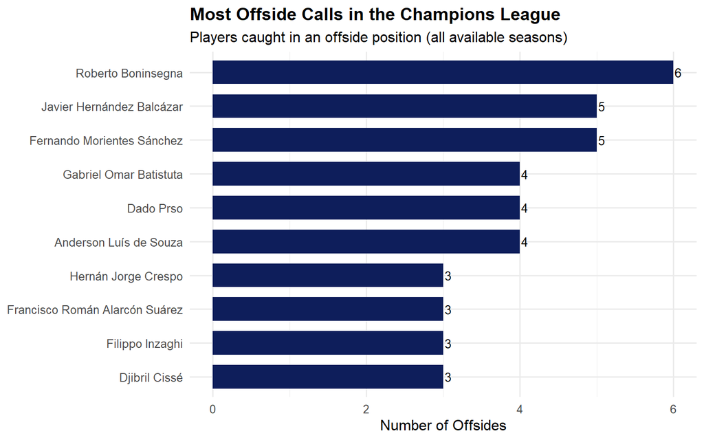

Top 10 players caught offside in the Champions League. Players at the top of this list are high-volume attackers who consistently push the defensive line.

```r
ggplot(top_10_offsides,
       aes(x = reorder(offside_player, offside_count), y = offside_count)) +
  geom_bar(stat = "identity", fill = "#0E1E5B", width = 0.7) +
  geom_text(aes(label = offside_count), hjust = -0.2, size = 3.5) +
  coord_flip() +
  labs(
    title = "Most Offside Calls in the Champions League",
    subtitle = "Players caught in an offside position (all available seasons)",
    x = NULL,
    y = "Number of Offsides"
  ) +
  theme_minimal(base_size = 12) +
  theme(plot.title = element_text(face = "bold"))
```

The players at the top of this list are primarily center-forwards and wide attackers who make frequent runs in behind. While a high offside count is not inherently negative — it shows aggression and pressure on the defensive line — it does indicate moments where a goal opportunity was immediately cancelled. Defenders who can reliably set and hold an offside trap effectively neutralize these attacking runs.

# 4 Home vs. Away Scoring

## 4.1 Do home teams have a meaningful scoring advantage?

Home field advantage is one of the most studied phenomena in sports analytics. We compare average goals scored and the distribution of match outcomes across home and away settings.

```r
Matches <- Matches %>%
  mutate(total_goals = home_score + away_score)

avg_total_goals <- round(mean(Matches$total_goals, na.rm = TRUE), 2)
avg_home_goals  <- round(mean(Matches$home_score,  na.rm = TRUE), 2)
avg_away_goals  <- round(mean(Matches$away_score,  na.rm = TRUE), 2)

goals_summary <- tibble(
  Metric   = c("Average Total Goals / Match", "Average Home Goals / Match", "Average Away Goals / Match"),
  Value    = c(avg_total_goals, avg_home_goals, avg_away_goals)
)
```

Average goals per match in Champions League fixtures.

| Metric | Value |
| --- | --- |
| Average Total Goals / Match | 3.00 |
| Average Home Goals / Match | 1.61 |
| Average Away Goals / Match | 1.39 |

Home teams average **1.61** goals per match compared to **1.39** for away sides — a difference of 0.22 goals per game. Over a two-leg tie, that gap can be decisive.

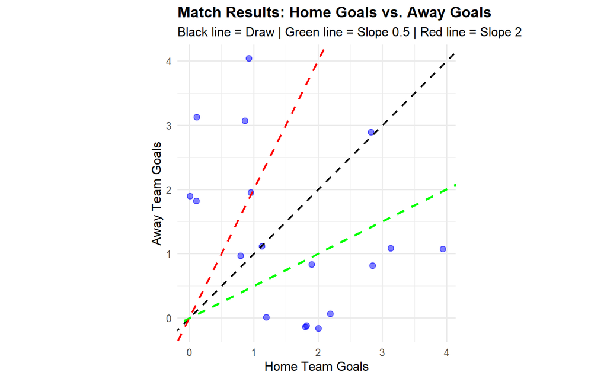

When slope = 1, the line follows away_score = home_score. Any match dot sitting on this line ended in a draw. Dots above it mean the away team scored more; dots below it mean the home team scored more. This line follows away_score = 0.5 × home_score, meaning the away team scored half what the home team did. Dots between the black and green lines represent matches where the home team won, but not by a huge margin. Dots below the green line indicate strong home dominance, the home team scored at least double the away team’s goals. This line follows away_score = 2 × home_score, the mirror image of the green line. Dots above the red line indicate strong away dominance, the away team scored at least double the home team’s goals.

```r
ggplot(Matches, aes(x = home_score, y = away_score)) +
  geom_jitter(width = 0.2, height = 0.2, alpha = 0.5, color = "blue", size = 2.5) +
  geom_abline(intercept = 0, slope = 1,   linetype = "dashed", color = "black",  linewidth = 0.8) +
  geom_abline(intercept = 0, slope = 0.5, linetype = "dashed", color = "green", linewidth = 1) +
  geom_abline(intercept = 0, slope = 2,   linetype = "dashed", color = "red",    linewidth = 1) +
  coord_fixed(ratio = 1) +
  labs(
    title    = "Match Results: Home Goals vs. Away Goals",
    subtitle = "Black line = Draw | Green line = Slope 0.5 | Red line = Slope 2",
    x = "Home Team Goals",
    y = "Away Team Goals"
  ) +
  theme_minimal(base_size = 12) +
  theme(plot.title = element_text(face = "bold"))
```

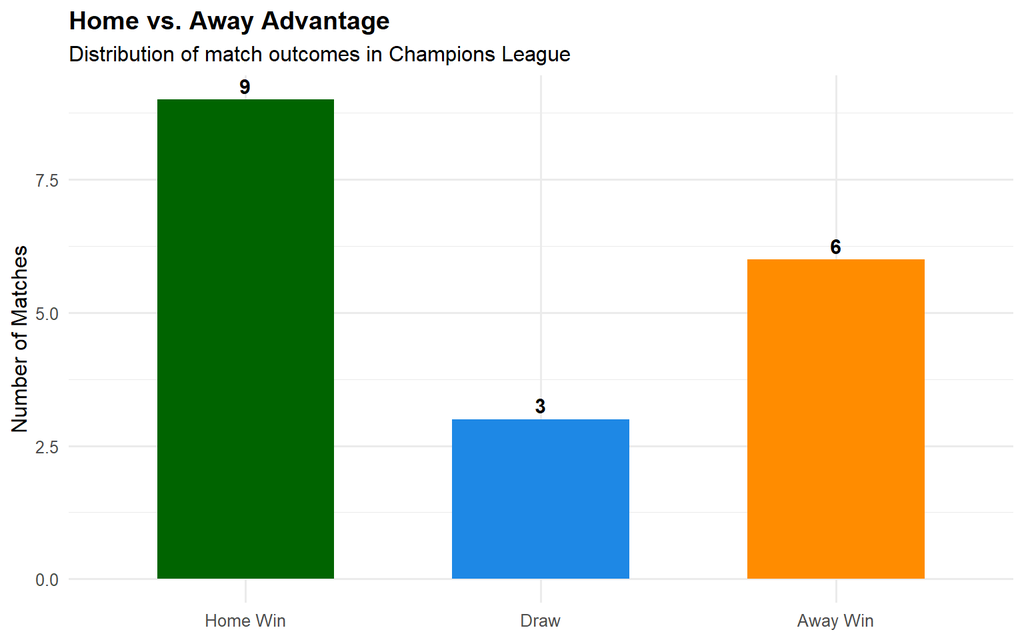

Counts of home wins, away wins, and draws across all available Champions League matches. Home teams win the most frequently, reinforcing the home advantage finding.

```r
matches_results <- Matches %>%
  mutate(result = case_when(
    home_score > away_score ~ "Home Win",
    home_score < away_score ~ "Away Win",
    TRUE                    ~ "Draw"
  ))

home_away_counts <- matches_results %>%
  group_by(result) %>%
  summarise(count = n(), .groups = "drop") %>%
  mutate(result = factor(result, levels = c("Home Win", "Draw", "Away Win")))

ggplot(home_away_counts, aes(x = result, y = count, fill = result)) +
  geom_col(width = 0.6, show.legend = FALSE) +
  geom_text(aes(label = count), vjust = -0.4, fontface = "bold", size = 4) +
  scale_fill_manual(values = c("Home Win" = "#006400", "Draw" = "#1E88E5", "Away Win" = "#FF8C00")) +
  labs(
    title = "Home vs. Away Advantage",
    subtitle = "Distribution of match outcomes in Champions League",
    x = NULL,
    y = "Number of Matches"
  ) +
  theme_minimal(base_size = 12) +
  theme(plot.title = element_text(face = "bold"))
```

# 5 Defensive Actions & Match Outcomes

## 5.1 Does higher defensive volume correlate with winning?

We measure “defensive output” as the combined count of tackles, interceptions, clearances, blocks, and pressures a team makes in a given match, then compare average counts across win, draw, and loss outcomes.

```r
defensive_events <- champLeagues_events %>%
  filter(type.name %in% c("Pressure", "Tackle", "Interception", "Clearance", "Block")) %>%
  group_by(match_id, team.name) %>%
  summarise(defensive_actions = n(), .groups = "drop")

team_match_outcomes <- bind_rows(
  Matches %>% select(match_id,
                     team.name    = home_team.home_team_name,
                     goals_for    = home_score,
                     goals_against = away_score),
  Matches %>% select(match_id,
                     team.name    = away_team.away_team_name,
                     goals_for    = away_score,
                     goals_against = home_score)
) %>%
  mutate(outcome = case_when(
    goals_for > goals_against ~ "Win",
    goals_for < goals_against ~ "Loss",
    TRUE                      ~ "Draw"
  ))

defense_summary <- team_match_outcomes %>%
  inner_join(defensive_events, by = c("match_id", "team.name")) %>%
  group_by(outcome) %>%
  summarise(avg_actions = round(mean(defensive_actions, na.rm = TRUE), 1),
            .groups = "drop") %>%
  mutate(outcome = factor(outcome, levels = c("Loss", "Draw", "Win")))
```

Average defensive actions (tackles, interceptions, clearances, blocks, pressures) by match outcome.

| Outcome | Avg. Defensive Actions |
| --- | --- |
| Draw | 241.0 |
| Loss | 175.7 |
| Win | 182.3 |

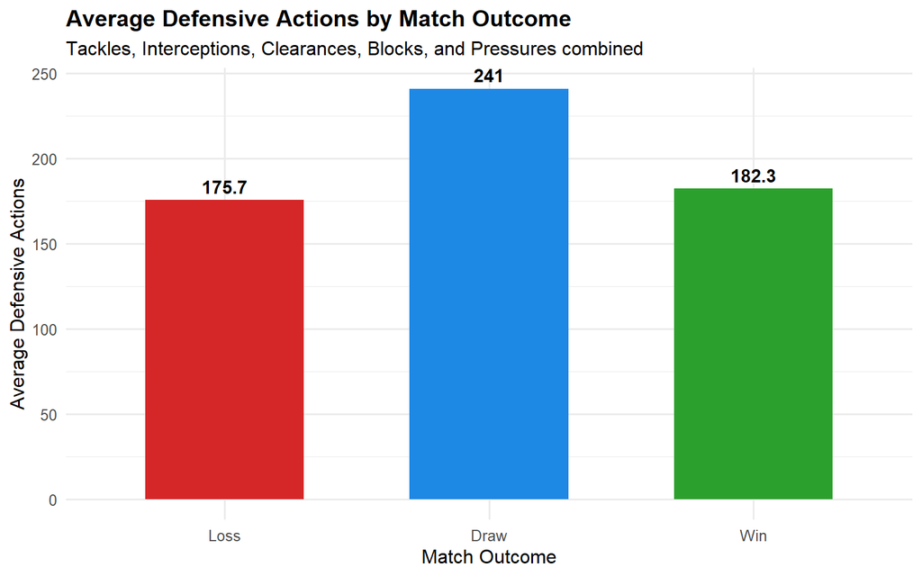

```r
ggplot(defense_summary, aes(x = outcome, y = avg_actions, fill = outcome)) +
  geom_col(width = 0.6, show.legend = FALSE) +
  geom_text(aes(label = avg_actions), vjust = -0.5, size = 4, fontface = "bold") +
  scale_fill_manual(values = c("Win" = "#2ca02c", "Draw" = "#1E88E5", "Loss" = "#d62728")) +
  labs(
    title    = "Average Defensive Actions by Match Outcome",
    subtitle = "Tackles, Interceptions, Clearances, Blocks, and Pressures combined",
    x        = "Match Outcome",
    y        = "Average Defensive Actions"
  ) +
  theme_minimal(base_size = 12) +
  theme(plot.title = element_text(face = "bold"))
```

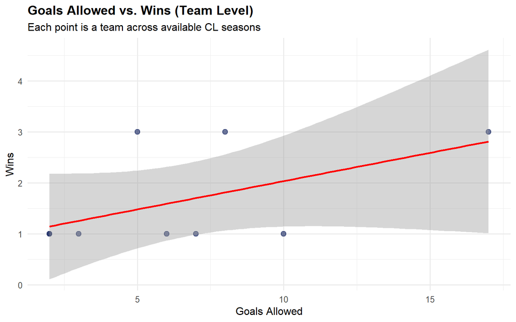

```r
# Goals allowed per team (from shot data, goals conceded)
ga <- champLeagues_events %>%
  filter(type.name == "Shot", shot.outcome.name == "Goal") %>%
  group_by(team.name) %>%
  summarise(ga = n(), .groups = "drop")

wins <- matches_results %>%
  mutate(w = case_when(
    result == "Home Win" ~ home_team.home_team_name,
    result == "Away Win" ~ away_team.away_team_name
  )) %>%
  filter(!is.na(w)) %>%
  group_by(w) %>%
  summarise(wins = n(), .groups = "drop")

df <- ga %>%
  rename(team = team.name) %>%
  inner_join(wins, by = c("team" = "w")) %>%
  filter(wins < 100)  # remove multi-season aggregates that distort scale

ggplot(df, aes(x = ga, y = wins)) +
  geom_point(alpha = 0.6, color = "#0E1E5B", size = 2.5) +
  geom_smooth(method = "lm", se = TRUE, color = "red", linewidth = 1) +
  labs(
    title    = "Goals Allowed vs. Wins (Team Level)",
    subtitle = "Each point is a team across available CL seasons",
    x = "Goals Allowed",
    y = "Wins"
  ) +
  theme_minimal(base_size = 12) +
  theme(plot.title = element_text(face = "bold"))
```

# 6 Shot Zones & Conversion Rates

## 6.1 Where do Champions League shots come from, and which zones convert?

We analyzed all open-play shots to understand how a shot’s location on the field relates to the likelihood of scoring. Shots were classified into distance bands based on how far they were taken from the goal and their lateral position(center, left, right).

```r
champLeagues_shots <- champLeagues_events %>%
  filter(type.name == "Shot") %>%
  select(id, match_id, period, minute, team.name, player.name,
         location, shot.end_location, shot.first_time,
         shot.technique.name, shot.body_part.name,
         shot.type.name, shot.statsbomb_xg,
         shot.outcome.name)

champLeagues_shots_xy <- champLeagues_shots %>%
  filter(!is.na(location), shot.type.name != "Penalty") %>%
  mutate(
    x      = map_dbl(location, 1),
    y      = map_dbl(location, 2),
    is_goal = shot.outcome.name == "Goal"
  )

get_distance_band <- Vectorize(function(x) {
  if (x >= 102)      "Inside the Box (<18 yds)"
  else if (x >= 84)  "Edge of the Box (18-36 yds)"
  else if (x >= 72)  "Long Range (36-48 yds)"
  else               "Very Long Range (48+ yds)"
})

get_lateral_zone <- Vectorize(function(y) {
  if (y >= 30 & y <= 50) "Central"
  else if (y < 30)       "Right Side"
  else                   "Left Side"
})

pitch_zones <- champLeagues_shots_xy %>%
  filter(x >= 60) %>%
  mutate(
    distance_band = get_distance_band(x),
    lateral_zone  = get_lateral_zone(y)
  ) %>%
  group_by(distance_band, lateral_zone) %>%
  summarise(
    total_shots     = n(),
    goals           = sum(is_goal, na.rm = TRUE),
    conversion_rate = round(goals / total_shots * 100, 1),
    .groups = "drop"
  ) %>%
  arrange(desc(conversion_rate))
```

Shot counts and conversion rates by pitch zone (open play and free kicks only).

| Distance Band | Lateral Zone | Total Shots | Goals | Conversion Rate (%) |
| --- | --- | --- | --- | --- |
| Inside the Box (<18 yds) | Central | 199 | 40 | 20.1 |
| Inside the Box (<18 yds) | Left Side | 55 | 3 | 5.5 |
| Edge of the Box (18-36 yds) | Left Side | 47 | 2 | 4.3 |
| Edge of the Box (18-36 yds) | Central | 159 | 5 | 3.1 |
| Inside the Box (<18 yds) | Right Side | 44 | 1 | 2.3 |
| Edge of the Box (18-36 yds) | Right Side | 44 | 0 | 0.0 |
| Long Range (36-48 yds) | Central | 9 | 0 | 0.0 |
| Long Range (36-48 yds) | Left Side | 2 | 0 | 0.0 |
| Very Long Range (48+ yds) | Central | 1 | 0 | 0.0 |

The table shows us a striking story. Shots taken from inside the box, centrally, produced 40 goals from 199 attempts, giving a scoring rate of 20.1% This is by far the most productive zone on the pitch to strike from. Once you move to the sides of the box, the efficiency score rate drops to 5.5% on the left and just 2.3% on the right. Shots from the edge of the box rarely result in goals, with score rates between 0% and 4.3% depending on the angle. At long range, no goals were scored at all across any lateral zone.

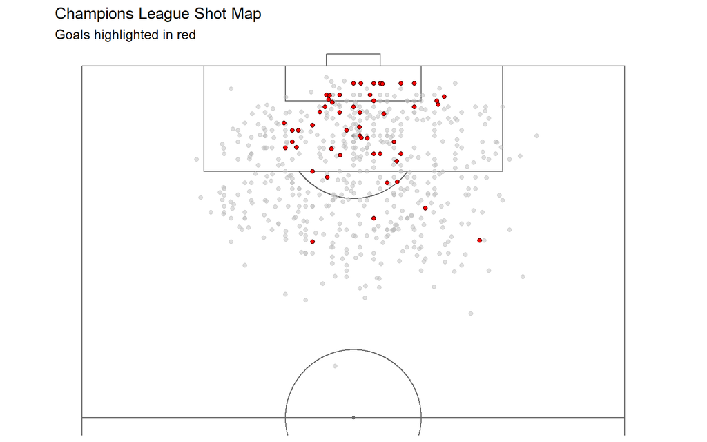

```r
all_shots  <- champLeagues_shots_xy
shot_goals <- champLeagues_shots_xy %>% filter(is_goal)

ggplot()+
  annotate_pitch(dimensions = pitch_statsbomb)+
  theme_pitch()+
  coord_flip(xlim = c(60,120),
             ylim = c(0,80)) +
  geom_point(data = all_shots,
             aes(x = x, y = y),
             color = "gray", alpha = 0.5) +
  geom_point(data = shot_goals,
             aes(x = x, y = y),
             shape = 21, fill ="red") +
 labs(title = "Champions League Shot Map",
      subtitle = "Goals highlighted in red")
```

The shot map is used to visualize the exact location of the shot and if it resulted in a score. The gray dots represent all open-play shots, and the red dots mark goals. Almost every red dot is clustered tightly in front of the goal, inside or just around the penalty area. You can see that while players attempt to strike from different locations in the field, the ones that actually result in goals are almost exclusively from close range and through the middle.

# 7 xG and Shot Distance

## 7.1 How does expected goals (xG) decay with distance?

Expected goals (xG) is a statistical estimate of the probability that a given shot results in a goal, based on historical shot data. It accounts for shot location, angle, technique, and context. Here we visualize how xG changes as distance from goal increases.

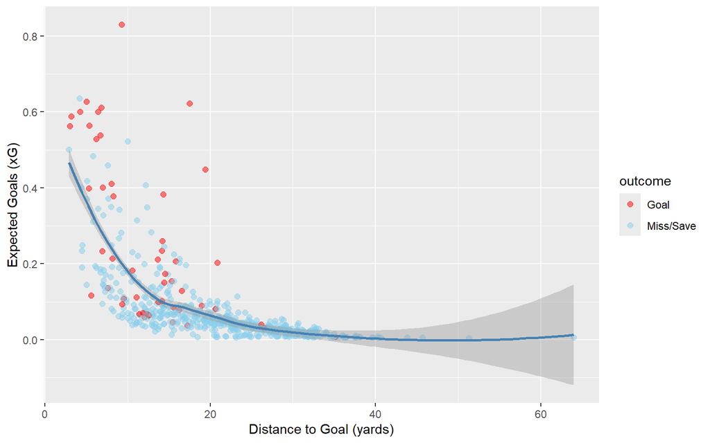

Expected goals (xG) falls sharply as distance from goal increases. Goals (red) cluster heavily in high-xG, short-distance zones, while most long-range shots carry xG values near zero.

```r
xg_distance_data <- champLeagues_shots_xy %>%
  filter(shot.type.name != "Penalty") %>%
  mutate(
    distance_to_goal = sqrt((120 - x)^2 + (40 - y)^2),
    outcome = ifelse(is_goal == TRUE, "Goal", "Miss/Save")
  )

ggplot(xg_distance_data,
       aes(x = distance_to_goal,
           y = shot.statsbomb_xg)) +
  geom_point(aes(color = outcome),
             alpha = 0.5, size = 2) +
  geom_smooth(method = "loess", color = "steelblue") +
  scale_color_manual(values = c("Goal" = "red", "Miss/Save" = "skyblue")) +
  labs(x = "Distance to Goal (yards)",
       y = "Expected Goals (xG)")
```

The graph shows us a significant trend. As distance increases, xG drops rapidly and approaches zero. Shots taken from inside 10 yards carry xG values regularly above 0.3 and sometimes above 0.6, meaning the model considers them more likely to result in a goal. By the time a player is 20 yards out, xG values are mostly clustered below 0.1.

The red dots (goals) follow this pattern well, with most of them appearing on the left side of the chart where distance is short and xG is high. There are a handful of outliers, with a few red dots appearing further out, representing goals scored from longer range despite the low xG.

# 8 Penalty Kick Analysis

## 8.1 How often do penalties result in goals?

```r
champLeagues_penalty_shots <- champLeagues_shots %>%
  filter(shot.type.name == "Penalty")
```

Penalty kicks are awarded when a foul is committed by the defending team inside their own penalty area. It is a one-on-one between the goalkeeper and a striker, with the ball located in the penalty spot, 12 yards from the center of the goal, and all other players outside the penalty box until the ball is struck. Because of this setup, penalty kicks have the highest xG situation in all of soccer. While open-play shots from inside the box centrally scored around 20% in our dataset, penalties converted at 69.7%. The xG model assigns penalty kicks values typically around 0.76, depending on the league, which means that nearly 3 out of 4 penalties are expected to result in a goal. No other situation comes this close to that level, which is why drawing fouls inside the penalty are is considered on of the most valuable outcomes for a team to create.

Overall penalty kick outcomes in Champions League data.

| Total Penalties | Goals Scored | Saved | Off Target | Hit Post | Scoring Rate (%) |
| --- | --- | --- | --- | --- | --- |
| 33 | 23 | 7 | 1 | 2 | 69.7 |

Out of all 33 recorded penalties kicks across our dataset, 23 resulted in goals, giving an overall scoring rate of 69.7%. Only 7 penalties were saved by the goalkeeper, 2 struck the post, and just 1 was off target entirely.

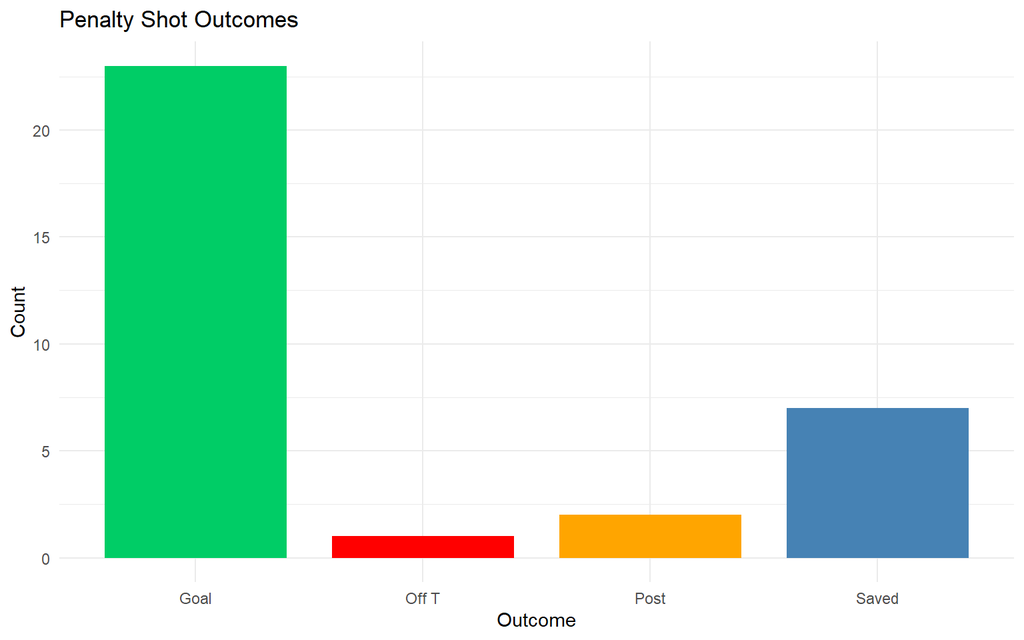

```r
ggplot(champLeagues_penalty_shots, aes(x = shot.outcome.name, fill = shot.outcome.name)) +
  geom_bar(width = .8, show.legend = FALSE) +
  scale_fill_manual(values = c("Goal" = "springgreen3",
                    "Off T" = "red",
                    "Post" = "orange",
                    "Saved" = "steelblue"))+
  labs(title = "Penalty Shot Outcomes",
       x = "Outcome",
       y = "Count") +
  theme_minimal() +
  theme(legend.position = "none")
```

The bar graph gives us a visual of this data, showing how the green “Goal” bar overextend the other outcomes. At elite level of soccer, penalties are converted at a high rate, with goalkeepers barely being able to stop them. Even while being the most common way a penalty does not score, goalkeeper saves account of only about 21% of all attempts.

## 8.2 Does foot preference affect penalty conversion?

Breaking the penalty data down further, we analyzed whether the foot a player uses to strike the ball influences how likely they are to score

Penalty conversion rates by foot used.

| Body Part | Total | Goals | Conversion (%) |
| --- | --- | --- | --- |
| Right Foot | 21 | 17 | 81 |
| Left Foot | 12 | 6 | 50 |

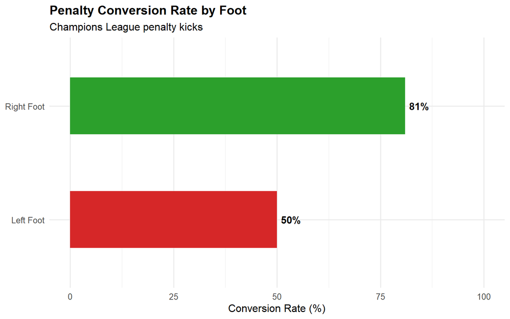

```r
body_part_analysis %>%
  ggplot(aes(x = `Body Part`, y = `Conversion (%)`, fill = `Body Part`)) +
  geom_col(width = 0.5, show.legend = FALSE) +
  geom_text(aes(label = paste0(`Conversion (%)`, "%")),
            hjust = -0.2, size = 4, fontface = "bold") +
  coord_flip() +
  scale_fill_manual(values = c("Right Foot" = "#2ca02c", "Left Foot" = "#d62728")) +
  ylim(0, 100) +
  labs(
    title    = "Penalty Conversion Rate by Foot",
    subtitle = "Champions League penalty kicks",
    x = NULL,
    y = "Conversion Rate (%)"
  ) +
  theme_minimal(base_size = 12) +
  theme(plot.title = element_text(face = "bold"))
```

Right-footed penalties were far more common, accounting for 21 of the 33 attempts, and converted at a rate of 81%. Left-footed penalties, while being less frequent at 12 attempts, scored only 50%. It is worth noting that there are other factors like placement, composure, and technique that could affect the conversion rate of penalty kicks, meaning the outcome is not solely depending on the foot used. As well as the relatively small sample size, these figures are better treated as an interesting observation than a definitely conclusion.

# 9 Conclusion

**Limitations:** The StatsBomb free data covers a subset of Champions League seasons and does not include all competitions. Some analyses (particularly team-level win totals) aggregate across multiple seasons, which can blur year-to-year tactical evolution. Future work could isolate individual seasons or control for team quality when analyzing defensive output.

*Data source: [StatsBomb Open Data](https://github.com/statsbomb/open-data). Analysis performed in R using `StatsBombR`, `tidyverse`, `ggsoccer`, and `kableExtra`.*